# R: Plotting

3 February 2016

## Attribution/Resources

Much of this tutorial is comprised of information from https://github.com/DataScienceSpecialization/courses/ tree/master/04_ExploratoryAnalysis

and

https://www.rstudio.com/wp-content/uploads/2015/05/ggplot2-cheatsheet.pdf

## Background

- ggplot2 is an implementation of 'The Grammar of Graphics' by Leland Wilkinson and sits alongside the **base** and **lattice** graphics systems in R
- The basic idea is to **map** from data to **aesthetic** atributes (colour, shape, size) of **geometric** obejects (points, lines, bars)

### Base:

- build and add to the plot
- can't go backwards to adjust

### Lattice:

- entire plot created with single call
- margins/spacing automatically set since entire plot is specified at once
- really good for conditioning plots

### ggplot2:

- ggplot2 sits between **base** and **lattice** models for plotting
- lots of defaults specified but you can customise

## Basic Components of a ggplot2 Plot

- A *data frame*
- *aesthetic mappings*: how data are mapped to color, size
- *geoms*: geometric objects like points, lines, shapes.
- *facets*: for conditional plots.
- *stats*: statistical transformations like binning, quantiles, smoothing.
- *scales*: what scale an aesthetic map uses (example: male = red, female = blue).
- *coordinate system*

## Getting started

Make sure ggplot2 is installed and if it isn't install it

```r
#Make sure ggplot2 is installed
if(!require("ggplot2")) {
    install.packages("ggplot2")
    library(ggplot2)
  }
```

We'll use the iris dataset for the examples

```r
data(iris)
```

## qplot()

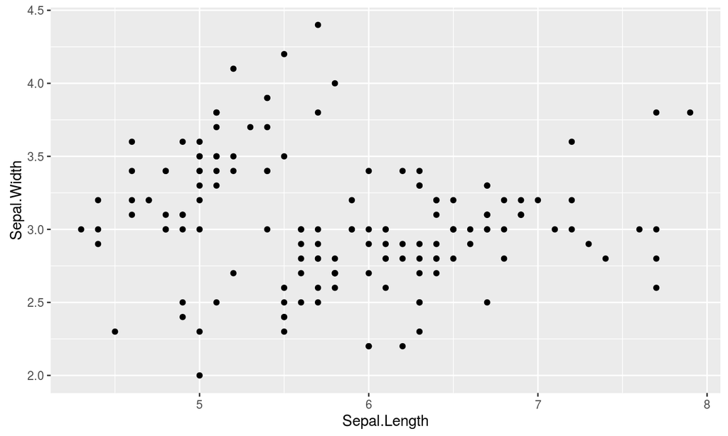

```r
qplot(Sepal.Length, Sepal.Width, data= iris)
```

Modify aesthetics

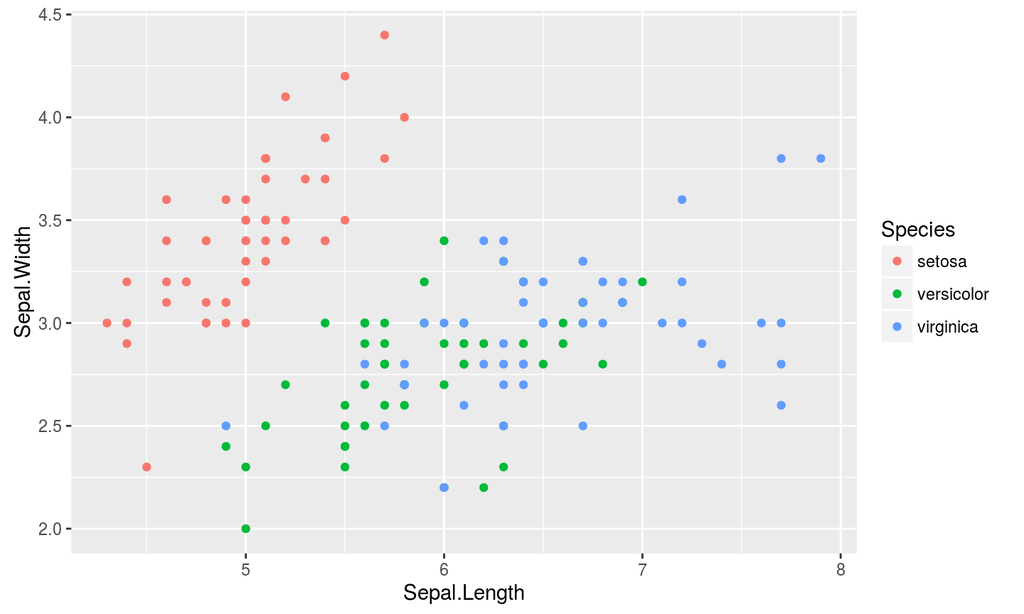

```r
qplot(Sepal.Length, Sepal.Width, data= iris, colour = Species)
```

Add a geom

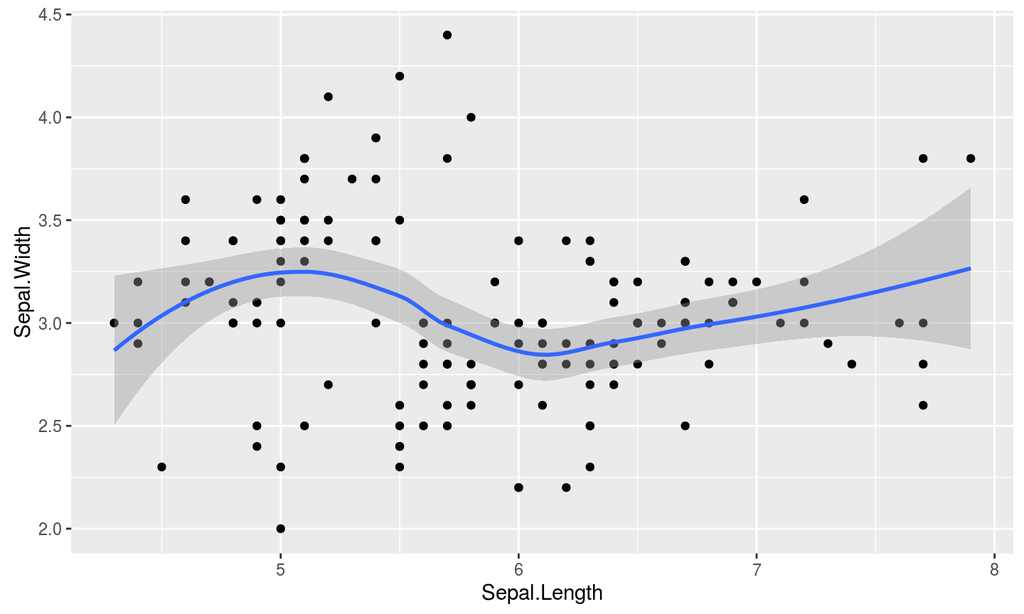

```r
qplot(Sepal.Length, Sepal.Width, data= iris, geom = c("point","smooth"))
```

## Moving from qplot() to ggplot()

- setup plot with ggplot() and define aesthetics
- add geom for points

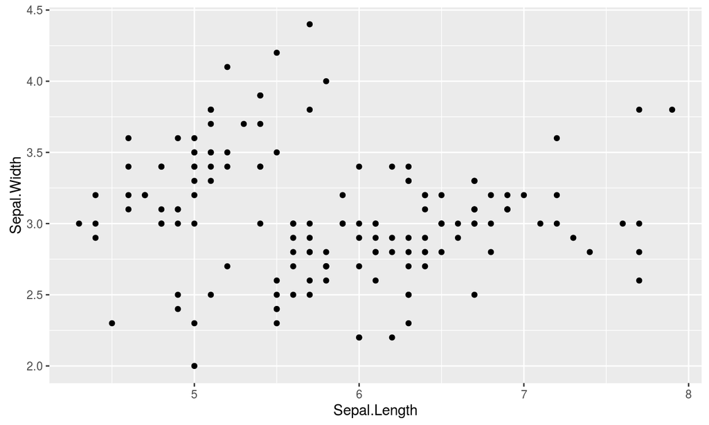

```r
ggplot(data = iris, aes(x=Sepal.Length, y =Sepal.Width)) +
  geom_point()
```

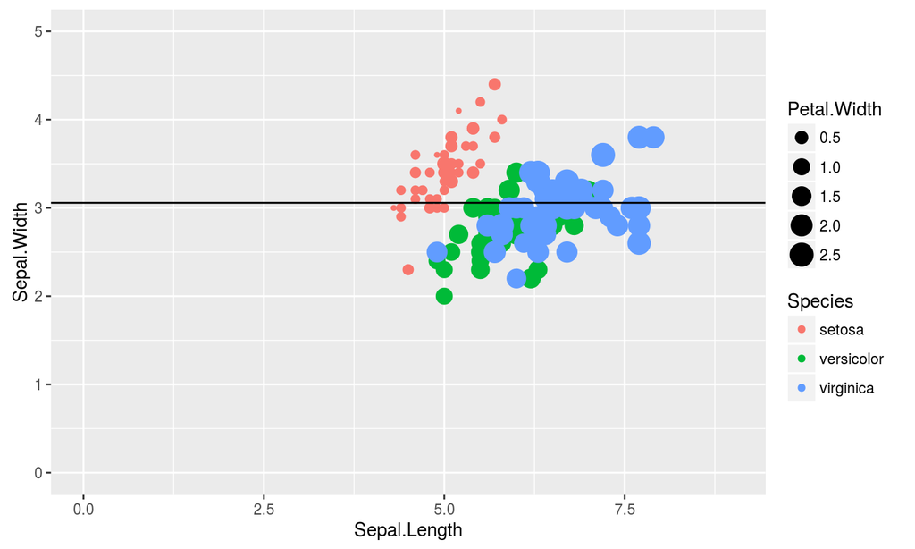

```r
ggplot(data = iris, aes(x=Sepal.Length, y =Sepal.Width)) +
  geom_point(aes(size=Petal.Width, colour = Species)) +
  geom_hline(yintercept = mean(iris$Sepal.Width)) +
  coord_cartesian(xlim = c(0,9), ylim=c(0,5))
```

## Histogram

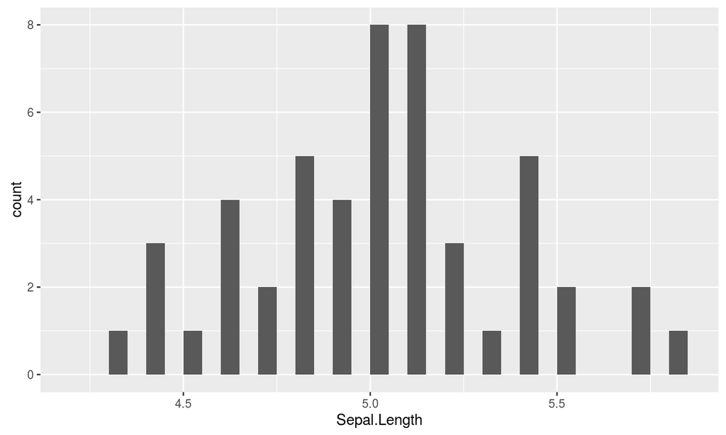

```r
ggplot(data = subset(iris, Species == "setosa"),
       aes(x=Sepal.Length)) +
  geom_histogram()
```

## Boxplots

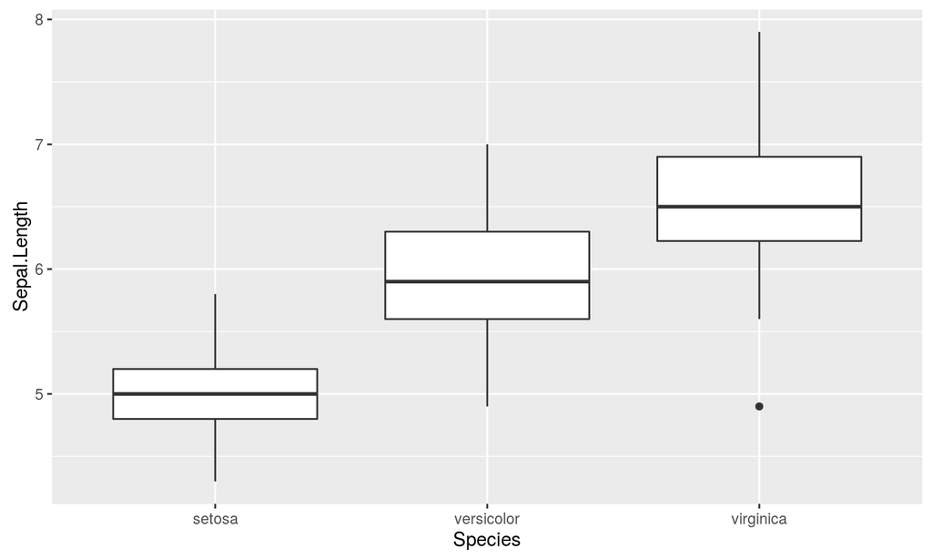

```r
ggplot(data = iris, aes(x=Species, y=Sepal.Length)) +
  geom_boxplot()
```

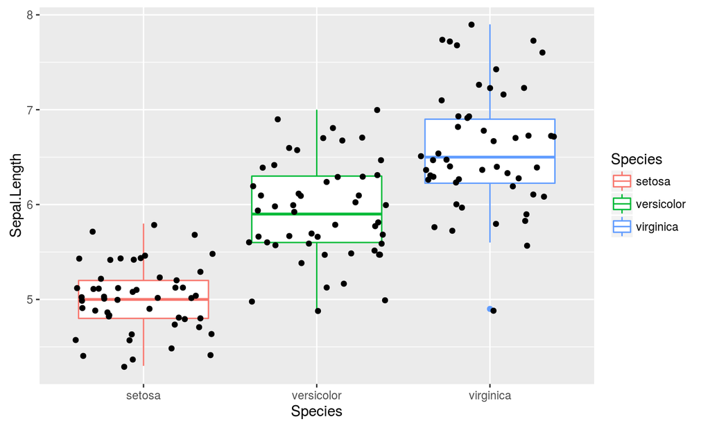

```r
ggplot(data = iris, aes(x=Species, y=Sepal.Length)) +
  geom_boxplot(aes(colour=Species)) +
  geom_jitter()
```

## Facetting

- wrap
- grid

## grid

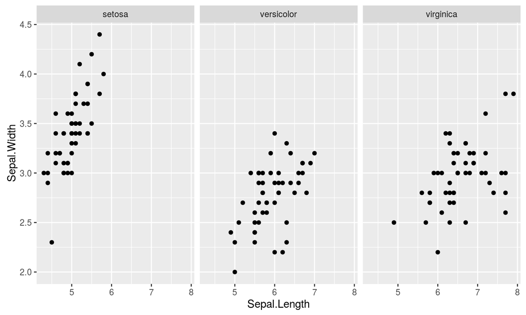

```r
ggplot(data = iris, aes(x=Sepal.Length, y =Sepal.Width)) +
  geom_point() +
  facet_grid(.~Species)
```

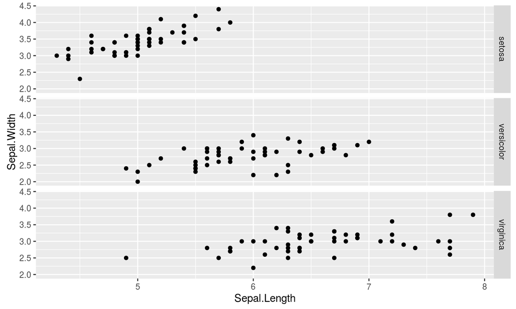

```r
ggplot(data = iris, aes(x=Sepal.Length, y =Sepal.Width)) +
  geom_point() +
  facet_grid(Species~.)
```

## Wrap

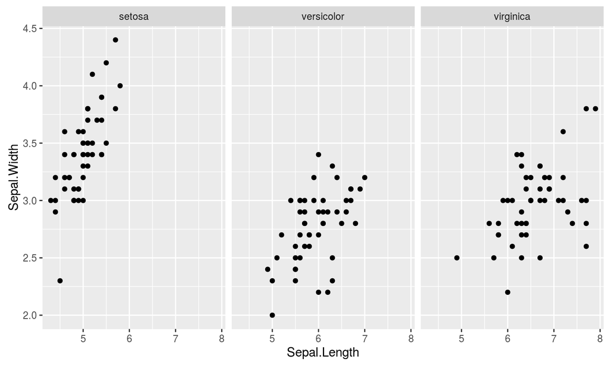

```r
ggplot(data = iris, aes(x=Sepal.Length, y =Sepal.Width)) +
  geom_point() +
  facet_wrap(~Species)
```

## Labels

- ggtitle()
- xlab()
- ylab()
- labs(title= "", x = "", y = "")

## Themes

- theme_bw()
- theme_grey()
- theme_classic()
- theme_minimal()

or change particular elements with **theme()** and specify which **element** to change

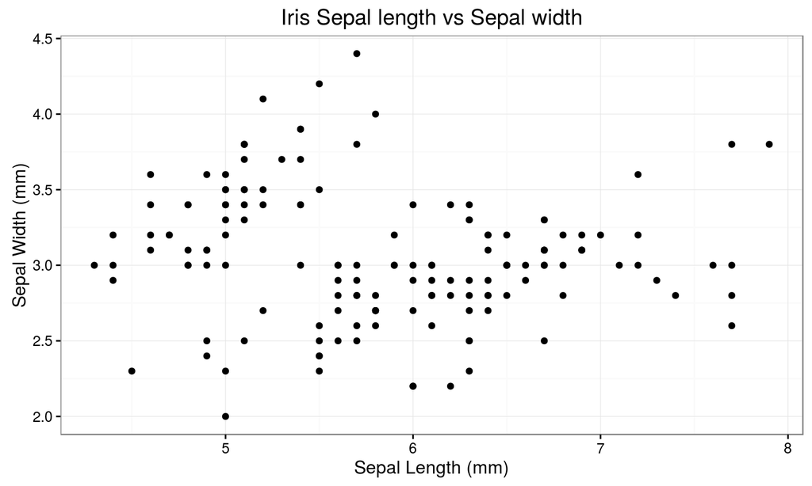

```r
ggplot(data = iris, aes(x=Sepal.Length, y =Sepal.Width)) +
  geom_point() +
  ggtitle("Iris Sepal length vs Sepal width") +
  xlab("Sepal Length (mm)")+
  ylab("Sepal Width (mm)") +
  theme_bw()
```

But with power comes responsibility…

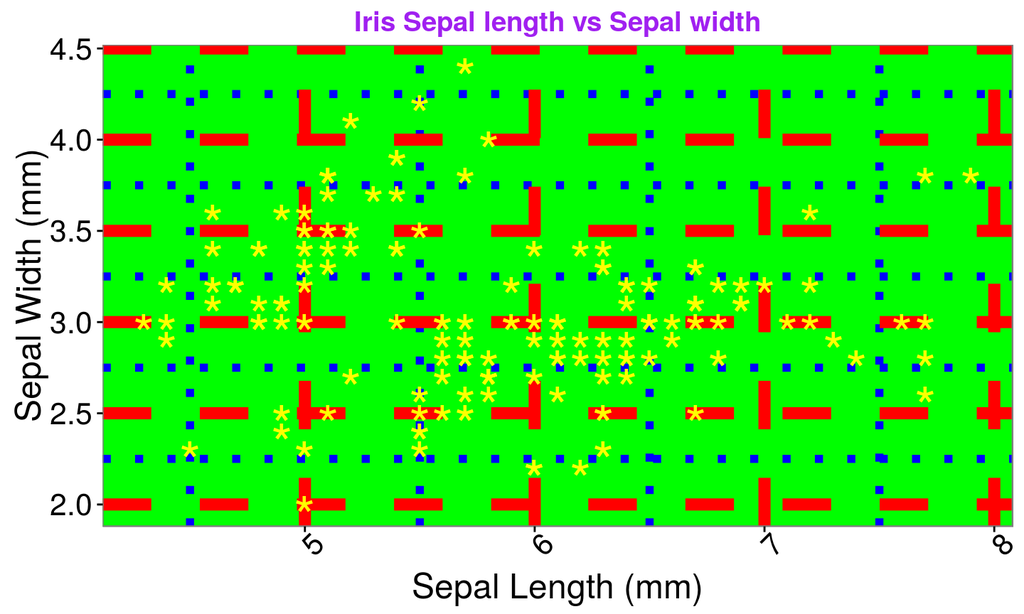

```r
ggplot(data = iris, aes(x=Sepal.Length, y =Sepal.Width)) +
  geom_point(colour="yellow", shape='*', size = 10) +
  ggtitle("Iris Sepal length vs Sepal width") +
  xlab("Sepal Length (mm)")+
  ylab("Sepal Width (mm)") +
  theme_bw() +
  theme(axis.text.x = element_text(size=16, angle = 45),
        axis.text.y = element_text(size=16),
        axis.title.x= element_text(size=18),
        axis.title.y = element_text(size=18),
        plot.title = element_text(colour = "purple", face='bold'),
        panel.grid.major = element_line(colour="red",
                                        linetype = "dashed", size = 3),
        panel.grid.minor = element_line(colour='blue',
                                        linetype='dotted', size=2),
        panel.background = element_rect(fill="#00FF00"))
```

## Resources

- http://docs.ggplot2.org/current/
- http://www.statmethods.net/advgraphs/ggplot2.html
- http://zevross.com/blog/2014/08/04/beautiful-plotting-in-r-a-ggplot2-cheatsheet-3/
- https://www.rstudio.com/wp-content/uploads/2015/05/ggplot2-cheatsheet.pdf